# Machine Learning Assignment

Stephen Checkley

June 2015

Using devices such as Jawbone Up, Nike FuelBand, and Fitbit it is now possible to collect a large amount of data about personal activity relatively inexpensively. These type of devices are part of the quantified self movement – a group of enthusiasts who take measurements about themselves regularly. One thing that people regularly do is quantify how much of a particular activity they do, but they rarely quantify how well they do it.

6 participants were asked to perform barbell lifts corrects and incorrectly in 5 different ways (A, B, C, D, and E) and data was collected from accelerometers on the belt, forearm, arm, and dumbbell of the participants.

The goal of this project is to predict the manner in which the exercise was performed.

# Obtaining the Exercise Data

```r
#import the data from the web
testing_url <- "https://d396qusza40orc.cloudfront.net/predmachlearn/pml-testing.csv"
training_url <-"https://d396qusza40orc.cloudfront.net/predmachlearn/pml-training.csv"

if (!file.exists("pml-testing.csv")) {
  download.file(testing_url, destfile="pml-testing.csv", method="curl")
}

if (!file.exists("pml-training.csv")) {
  download.file(training_url, destfile="pml-training.csv", method="curl")
}
```

# Importing and Cleaning the Data

```r
#load the data
data.testing <- read.csv("pml-testing.csv",na.strings=c("NA", "#DIV/0!"))
data.training <- read.csv("pml-training.csv",na.strings=c("NA", "#DIV/0!"))
#View(data.training)

#remove missing values
data.testing <- data.testing[, colSums(is.na(data.testing)) == 0]
data.training <- data.training[, colSums(is.na(data.training)) == 0]

#remove unnecessary columns
data.testing <- data.testing[ , !names(data.testing) %in% c("X", "user_name", "raw_timestamp_part_1", "raw_timestamp_part_2", "cvtd_timestamp", "new_window","num_window")]
data.training <- data.training[ , !names(data.training) %in% c("X", "user_name", "raw_timestamp_part_1", "raw_timestamp_part_2", "cvtd_timestamp", "new_window","num_window")]
data.testing$problem_id <- NULL
```

# Exploratory Data Analysis

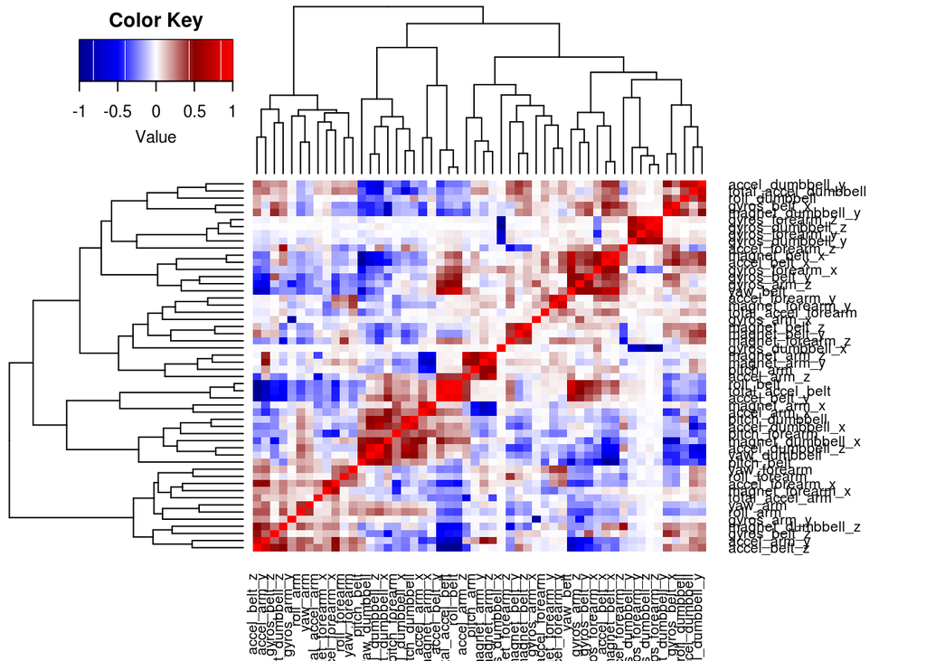

```r
data4map <- cor(data.training[, names(data.training) != "classe"])
my_palette <- colorRampPalette(c("darkblue", "blue", "white", "darkred", "red"))(n = 1000)
heatmap.2(data4map,
          col = my_palette,
          dendrogram="both",
          density.info = "none",
          trace="none",
          margins = c(5,10),
          key=TRUE,
          scale="none"
          )
```

# Preparation for Modelling

## Data Preparation

```r
inTrain <- createDataPartition(y = data.training$classe, p = 0.7, list = FALSE)
data4training <- data.training[inTrain, ] #training subset
data4testing <- data.training[-inTrain, ] #testing subset
```

The training data set is split with 70% allocated for training and 30% allocated to model testing.

## Model Preparation

```r
registerDoMC(cores = detectCores(logical=FALSE)) #set up parallel workers
set.seed(8418)
trControl <- trainControl(method = "cv", number = 10, allowParallel = TRUE, verboseIter = FALSE)
```

10-fold Cross validation is set, paralellized across all available CPU cores.

```r
modfit <- train(classe ~ ., data=data4training, method="rf", trControl=trControl, prox=FALSE)
modfit
```

```
## Random Forest
##
## 13737 samples
##    52 predictors
##     5 classes: 'A', 'B', 'C', 'D', 'E'
##
## No pre-processing
## Resampling: Cross-Validated (10 fold)
##
## Summary of sample sizes: 12363, 12364, 12364, 12364, 12363, 12364, ...
##
## Resampling results across tuning parameters:
##
##   mtry  Accuracy   Kappa      Accuracy SD  Kappa SD
##    2    0.9917013  0.9895013  0.002955537  0.003740182
##   27    0.9906091  0.9881201  0.003574927  0.004523292
##   52    0.9859506  0.9822250  0.004553919  0.005763434
##
## Accuracy was used to select the optimal model using  the largest value.
## The final value used for the model was mtry = 2.
```

Machine learning is applied to the training data subset using the Random Forest algorithm. The resulting model fit is reported to be 99% accurate using 52 predictors over 13737 samples (see Appendix for a map of the final model tree and details of variable importance).

## Model Validation

```r
modfit.test <- predict(modfit, newdata = data4testing)
cfMatrix <- confusionMatrix(data4testing$classe, modfit.test)
cfMatrix
```

```
## Confusion Matrix and Statistics
##
##           Reference
## Prediction    A    B    C    D    E
##          A 1672    2    0    0    0
##          B    3 1133    3    0    0
##          C    0    7 1018    1    0
##          D    0    0   23  939    2
##          E    0    0    0    1 1081
##
## Overall Statistics
##
##                Accuracy : 0.9929
##                  95% CI : (0.9904, 0.9949)
##     No Information Rate : 0.2846
##     P-Value [Acc > NIR] : < 2.2e-16
##
##                   Kappa : 0.991
##  Mcnemar's Test P-Value : NA
##
## Statistics by Class:
##
##                      Class: A Class: B Class: C Class: D Class: E
## Sensitivity            0.9982   0.9921   0.9751   0.9979   0.9982
## Specificity            0.9995   0.9987   0.9983   0.9949   0.9998
## Pos Pred Value         0.9988   0.9947   0.9922   0.9741   0.9991
## Neg Pred Value         0.9993   0.9981   0.9946   0.9996   0.9996
## Prevalence             0.2846   0.1941   0.1774   0.1599   0.1840
## Detection Rate         0.2841   0.1925   0.1730   0.1596   0.1837
## Detection Prevalence   0.2845   0.1935   0.1743   0.1638   0.1839
## Balanced Accuracy      0.9989   0.9954   0.9867   0.9964   0.9990
```

```r
missClass = function(values, model.test) {
  sum(model.test != values)/length(values)
}
error = missClass(data4testing$classe, modfit.test)
error
```

```
## [1] 0.007136788
```

# Model Predictions

Using the real testing data set the model predicts the following exercise classes from 20 observations:

```r
test.result <- predict(modfit, data.testing)
test.result
```

```
##  [1] B A B A A E D B A A B C B A E E A B B B
## Levels: A B C D E
```

# Appendix

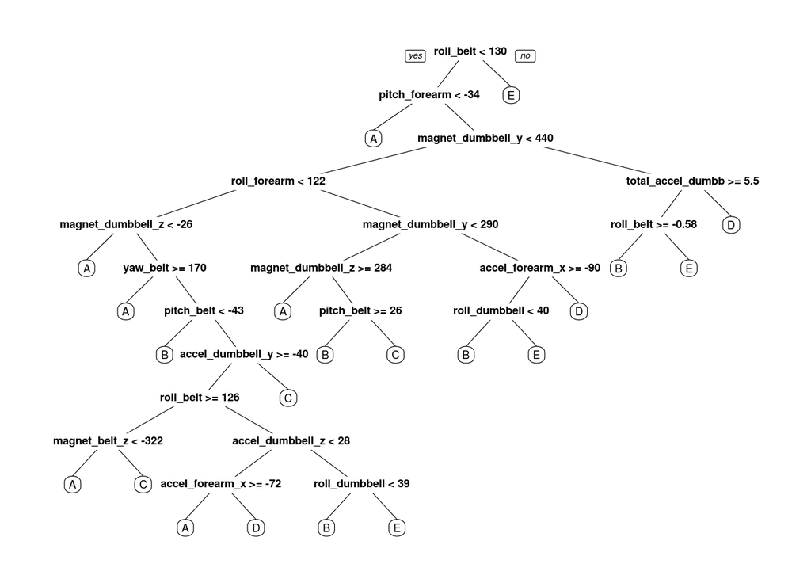

```r
prp(tree)
```

```r
varImp(modfit)
```

```
## rf variable importance
##
##   only 20 most important variables shown (out of 52)
##
##                      Overall
## roll_belt             100.00
## yaw_belt               82.69
## magnet_dumbbell_z      70.22
## magnet_dumbbell_y      68.32
## pitch_belt             65.13
## pitch_forearm          63.67
## magnet_dumbbell_x      54.41
## roll_forearm           52.29
## magnet_belt_y          48.33
## magnet_belt_z          46.06
## accel_belt_z           44.10
## roll_dumbbell          42.95
## accel_dumbbell_y       41.57
## accel_dumbbell_z       37.62
## roll_arm               36.77
## accel_forearm_x        32.07
## gyros_dumbbell_y       30.70
## gyros_belt_z           30.42
## accel_dumbbell_x       29.51
## total_accel_dumbbell   29.04
```

Analysis of variable importance for the model.